# Report of Wine Reviews: Demystifying the sophisticated alcohol

#### Data from: https://www.kaggle.com/zynicide/wine-reviews

#### Inspiration from: https://www.kaggle.com/graeme16161/wine-data-explore

Wines are just such delightful thing that life have given us, it is even an art to some. Those who practise this art are known as sommeliers. However, many question the subjectiveness in the field and are all this just a hoax.

Are costs of the wine justified by the ratings of the sommeliers? Are other factors at play to the pricing of wines? Let us dive into the realm of this sophisticated beverage.

- Clear out missing data

```r
wine_complete <- wine_complete[complete.cases(wine_complete),]
```

```r
head(wine_complete)
```

```
##   country
## 1      US
## 2   Spain
## 3      US
## 4      US
## 5  France
## 6   Spain
##                                                                                                                                                                                                                                                                                                          …
## 1                              This tremendous 100% varietal wine hails from Oakville and was aged over three years in oak. Juicy red-cherry fruit and a compelling hint of caramel greet the palate, framed by elegant, fine tannins and a subtle minty tone in the background. Balanced and rewarding f…
## 2                                                                     Ripe aromas of fig, blackberry and cassis are softened and sweetened by a slathering of oaky chocolate and vanilla. This is full, layered, intense and cushioned on the palate, with rich flavors of chocolaty black fruits and bak…
## 3                                                                                                           Mac Watson honors the memory of a wine once made by his mother in this tremendously delicious, balanced and complex botrytised white. Dark gold in color, it layers toasted hazelnut, pear co…
## 4 This spent 20 months in 30% new French oak, and incorporates fruit from Ponzi's Aurora, Abetina and Madrona vineyards, among others. Aromatic, dense and toasty, it deftly blends aromas and flavors of toast, cigar box, blackberry, black cherry, coffee and graphite. Tannins are polished to a fine…
## 5         This is the top wine from La BÃ©gude, named after the highest point in the vineyard at 1200 feet. It has structure, density and considerable acidity that is still calming down. With 18 months in wood, the wine has developing an extra richness and concentration. Produced by the Tari fami…
## 6                                                                        Deep, dense and pure from the opening bell, this Toro is a winner. Aromas of dark ripe black fruits are cool and moderately oaked. This feels massive on the palate but sensationally balanced. Flavors of blackberry, coffee, m…
##                             designation points price       province
```

[output cut: 20 more lines]

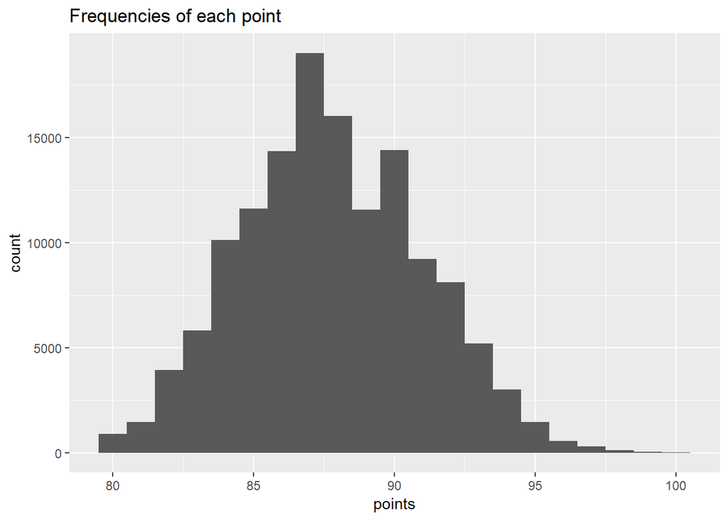

```r
ggplot(wine_complete, aes(x = points)) + geom_histogram(binwidth = 1) + ggtitle("Frequencies of each point")
```

- Points are a scale so they are rather self explanatory, a 99 points bottle must be better than a 98 point bottle. However, how do we differentiate good wine from bad wine? Thus, we still need to categorise the points to give meaning to the numbers.

```r
wine_complete$Grade<- cut(wine_complete$points, c(0,50,60,70,80,90,95,100), right = FALSE, labels = c("undrinkable", "not recommended", "Average", "Above Average", "Very good", "Superior", "Exceptional"))
```

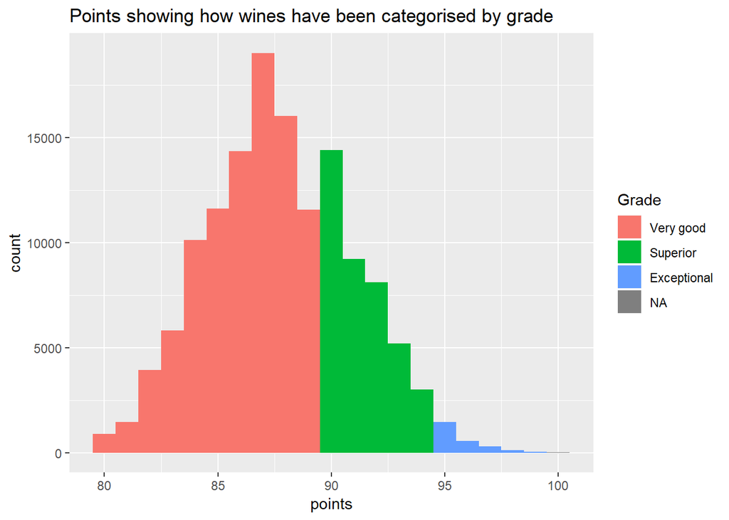

```r
ggplot(wine_complete, aes(x = points, fill = Grade)) + geom_histogram(binwidth = 1) + ggtitle("Points showing how wines have been categorised by grade")
```

- Now we will look at the distribution for price vs score

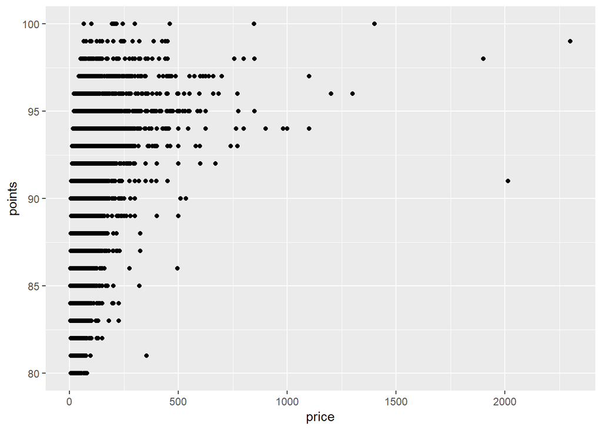

```r
ggplot(wine_complete, aes(x = price, y = points)) + geom_point()
```

- How “value for money” are wines then? We calculate the economic score of the wines to determine the number of scores per dollar paid for the wine.

```r
wine_complete$econ_score <- wine_complete$points / wine_complete$price
```

- Now we can take a look at the distribution of the economic score.

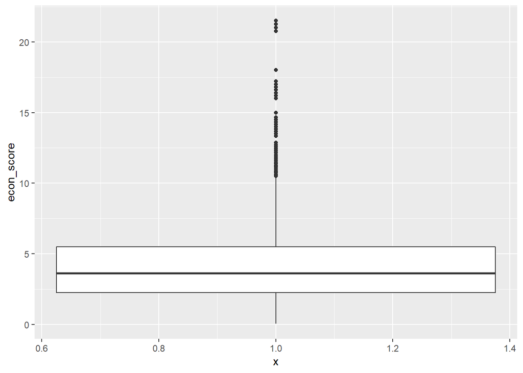

```r
ggplot(wine_complete, aes(x = 1, y = econ_score)) + geom_boxplot()
```